# Domača naloga 8

Natasa Kejzar

9.3.2019

# Naloga 8

Iz teoretičnih izpeljav za nek statistični test vemo, da pod $H_0$ zavrača točno z velikostjo $\alpha = 0,05$. Test smo sprogramirali, sedaj pa bi se radi s simulacijami prepričali, da nismo naredili kakšne napake. Zanima nas, ali sprogramirani test pod $H_0$ zares zavrača točno v 5%. Ker pri simulacijah nikoli ne moremo zagotovo nekaj trditi, bi radi pognali tolikšno število simulacij, da bomo lahko velikost tega testa ugotovili na $0,5$% natančno. Zanima nas torej, najmanj koliko simulacij moramo pognati za tako natančnost.

1. Zapišite, katera spremenljivka nas zanima in kako je porazdeljena.
2. Za oceno števila simulacij uporabite teoretično porazdelitev (ne asimptotske!).
   - Narišite graf, ki prikazuje širino intervala, kjer se nahaja srednjih 95% simuliranih vrednosti, v odvisnosti od števila simulacij. Komentirajte ugotovitve.
   - Kaj se zgodi v primeru, da test pod $H_0$ ne zavrača z velikostjo točno $\alpha$, ampak z večjo (npr. $0,07$)? Imamo v tem primeru če vedno dovolj natančne simulacije? Pokažite to (s simulacijami?).
   - Podajte teoretično razlago za prejšnjo točko.
3. Preverite, do kakšne mere bi bili rezultati zanesljivi, če bi računanje poenostavili z asimptotsko porazdelitvijo.

## 1. Spremenljivka

Zanima nas št.zavrnitev oz. delež zavrnitev. Št. zavrnitev je binomsko porazd.spremenljivka $X = Bin(n,\pi)$, kjer je $\pi = 0.05$, delež zavrnitev pa $D=\frac{X}{n}$. Zanima nas velikost vzorca (torej $n$), ko je širina med mejama zavrnitve največ 0.01.

## 2. Eksaktna porazdelitev

$$var(X) = n\pi(1-\pi)$$
Lahko delamo tudi z oceno variance $n\cdot \frac{n\pi(1-\pi)}{n-1}$

Varianca za delež pa je $\frac{\pi(1-\pi)}{n}$.

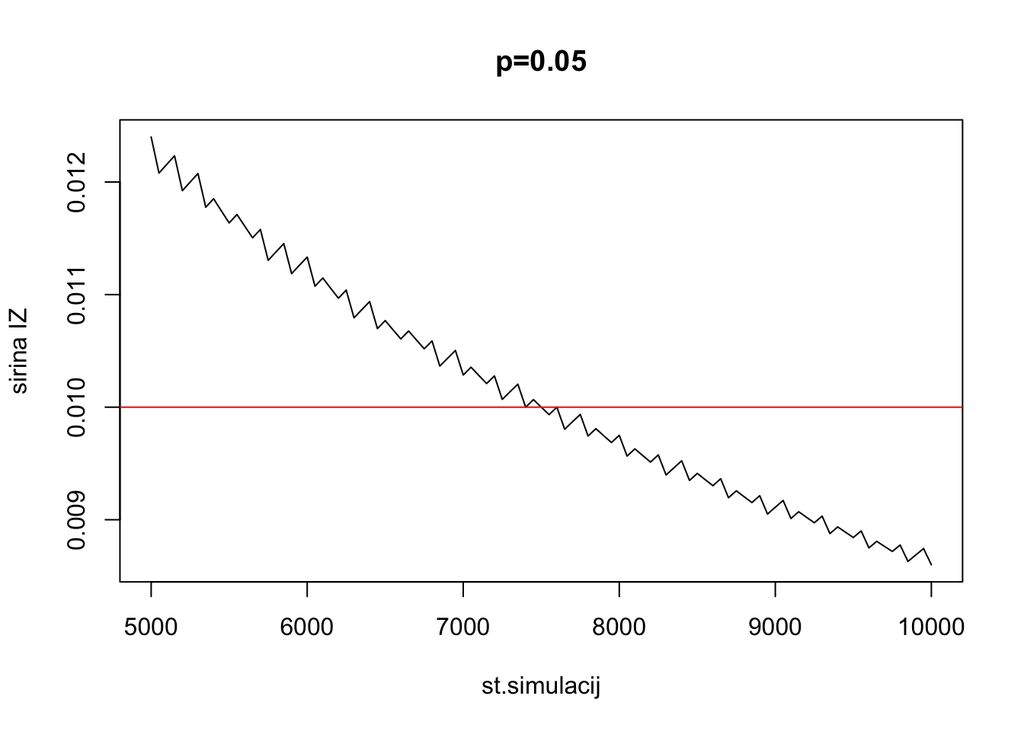

```r
p=0.05

meje = NULL
nji = seq(5000,10000,by=50)
for(n in nji){
  # izracunamo interval zaupanja za delez "p"
  k1 = (qbinom(0.025,size=n,prob=p)-1)/n
  k2 = qbinom(0.975,size=n,prob=p)/n
  # zgornji meji bi lahko izracunali tudi preko Clopper-Pearsonovega IZ za delez
  sirina = k2-k1
  meje = rbind(meje,c(k1,k2,sirina,n))
}
meje = as.data.frame(meje)
names(meje) = c("sp","zg","sirina","n")

plot(meje$n,meje$sirina,type="l",xlab="st.simulacij",ylab="sirina IZ",main="p=0.05")
abline(h=0.01,col="red")
```

Z velikostjo vzorca širina med mejama zavrnitve pada, vendar ne monotono. Nenadni skoki navzgor se zgodijo zaradi diskretnostni spremenljivke in s tem povezane velikosti za zavrnitev (za vsak $n$ je nemogoče dobiti mejo zavrnitve točno pri $\alpha$).

```r
inx = min(which((meje$sirina < 0.01)))
meje[inx,] # izracunano stevilo simulacij
```

```
##            sp         zg      sirina    n
## 52 0.04503311 0.05496689 0.009933775 7550
```

Za naš primer bi morali narediti vsaj 7550 simulacij.

### Primer, ko je $\pi = 0.07$

V tem primeru je razpršenost podatkov večja (bolj, kot gremo pri binomski porazdelitvi proti 0.5, večja je razpršenost porazdelitve pri istem $n$).

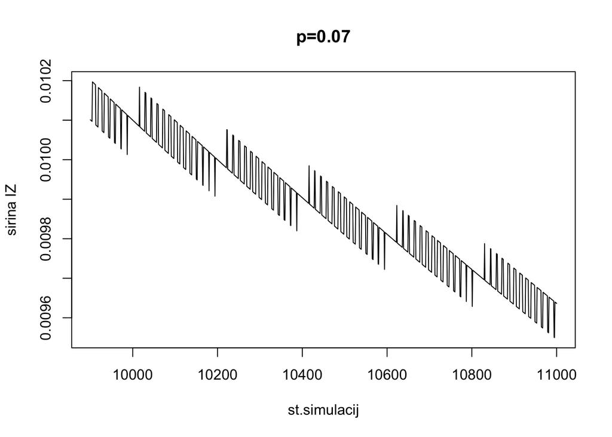

```r
izracunMej <- function(n,p){
  # meje zavrnitve pri dolocenem n
  k1 = (qbinom(0.025,size=n,prob=p)-1)/n
  k2 = qbinom(0.975,size=n,prob=p)/n
  sirina = k2-k1
  c(k1,k2,sirina,n)
}

nji = 9900:11000
temp=sapply(nji,FUN=izracunMej,p=0.07)
mejeA = as.data.frame(t(temp))
names(mejeA) = c("sp","zg","sirina","n")
plot(mejeA$n,mejeA$sirina,type="l",xlab="st.simulacij",ylab="sirina IZ",main="p=0.07")
```

```r
inx = min(which((mejeA$sirina < 0.01)))
```

[output not shown]

Za naš primer bi morali narediti vsaj 10106 simulacij, kar je več, kot prej. Širina med mejama zavrnitve je v tem primeru večja, saj je $\pi$ večji (bližje vrednosti 0.5, kjer je razpršenost binomsko porazdeljene spremenljivke največja).

## 3. Asimptotska porazdelitev

V tem primeru lahko širino med mejama zavrnitve izračunamo kot
$$2\cdot z_{1-\alpha/2}\cdot SE_{D} = 2\cdot z_{1-\alpha/2}\cdot \sqrt{\frac{\pi(1-\pi)}{n}}.$$
Veljati mora
$$\begin{align*}
2\cdot z_{1-\alpha/2}\cdot \sqrt{\frac{\pi(1-\pi)}{n}} &< 0.01 \\
\left(\frac{2\cdot z_{1-\alpha/2}}{0.01}\right)^2 \cdot \pi(1-\pi) &< n
\end{align*}$$

```r
p=0.05
(2*qnorm(0.975)/0.01)^2*p*(1-p) # vecje od 7299, teor 7550
```

```
## [1] 7298.772
```

```r
p=0.07
(2*qnorm(0.975)/0.01)^2*p*(1-p) # vecje od 10004, teor 10106
```

```
## [1] 10003.16
```